# LAGOS Spatial Analysis

Alex Siggers

02/24/22

# LAGOS Analysis

## Loading in data

### First download and then specifically grab the locus (or site lat longs)

# In-Class work

```r
iowa <- states %>%
  filter(name == 'Iowa') %>%
  st_transform(2163)

illinois <- states %>%
  filter(name == 'Illinois') %>%
  st_transform(2163)

mapview(iowa) +
  mapview(illinois)
```

[interactive chart not shown]

## 2) Subset LAGOS data to these sites, how many sites are in Illinois and Iowa combined? How does this compare to Minnesota?

```r
iowa_lakes <- spatial_lakes[iowa,]
illinois_lakes <- spatial_lakes[illinois,]
```

-Iowa has 4,644 lakes total, and Illinois has 11,822. This combines to about ~16,500+ lakes, which is about half as many as Minnesota contains (29,038). Minnesota has a ton of lakes.

## 3) What is the distribution of lake size in Iowa vs. Minnesota?

- Here I want to see a histogram plot with lake size on x-axis and frequency on y axis (check out geom_histogram)

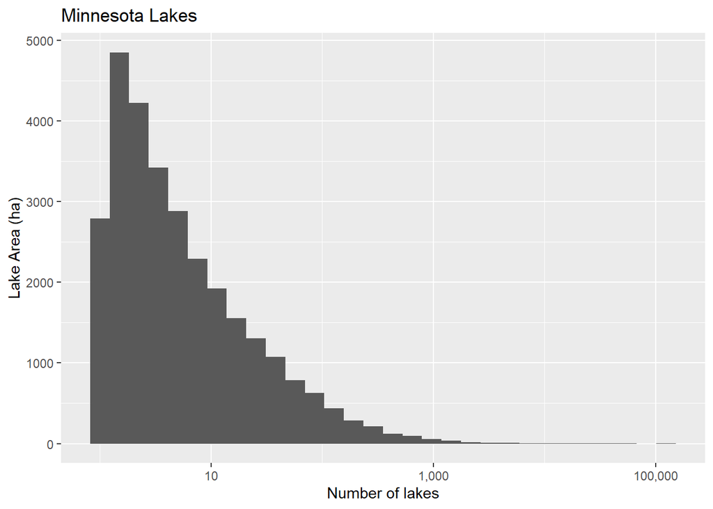

```r
ggplot(minnesota_lakes, aes(x= lake_area_ha)) +
  geom_histogram() +
  scale_x_log10(labels = scales::comma) +
  ylab("Lake Area (ha)") +
  xlab("Number of lakes") +
  ggtitle("Minnesota Lakes")
```

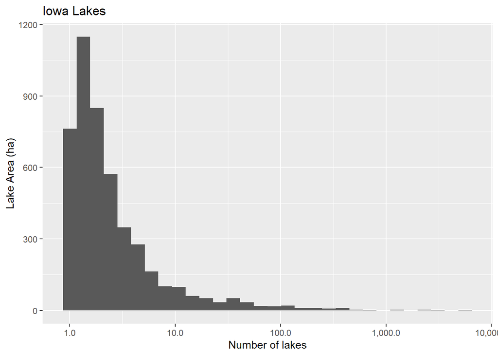

```r
ggplot(iowa_lakes, aes(x= lake_area_ha)) +
  geom_histogram() +
  scale_x_log10(labels = scales::comma) +
  ylab("Lake Area (ha)") +
  xlab("Number of lakes") +
  ggtitle("Iowa Lakes")
```

## 4) Make an interactive plot of lakes in Iowa and Illinois and color them by lake area in hectares

```r
Iowanois=rbind(iowa_lakes, illinois_lakes)

Iowanois %>%
  arrange(-lake_area_ha) %>%
    slice(1:1000) %>%
  mapview(.,zcol = 'lake_area_ha')
```

[interactive chart not shown]

## 5) What other data sources might we use to understand how reservoirs and natural lakes vary in size in these three states?

-Aquifer depletion/depth, precipitation, long-term climate data, and glacial movement data would help to explain these size differences. Land use change data might also help to explain the manmade lakes.